# Complex dosing schedules

Itziar Irurzun Arana

2019-07-25

We are going to simulate complex dosing schedules using mrgsolve and ACESO packages.

```r
#' Load libraries
library(ACESO)
library(mrgsolve)
#install mrgsolve from github: devtools::install_github("metrumresearchgroup/mrgsolve")
```

## Pharmacokinetic model

We are going to simulate a one compartment model with intravenous administration.

Read the model from the model libraries included in ACESO:

```r
model_library(list=T)
```

```
#> ACESO internal library of PK models:
#> [1] "1cmt_2depot" "1cmt_ev"     "1cmt_iv"     "2cmt_2depot" "2cmt_ev"
#> [6] "2cmt_iv"     "3cmt_ev"     "3cmt_iv"
```

```r
cmt1_iv <- mread("1cmt_iv", model_library()) %>% Req(CP)
```

```
#> Building 1cmt_iv ...
#> done.
```

```r
#See the code of the model
see(cmt1_iv)
```

```
#>
#> Model file:  1cmt_iv.cpp
#> $PARAM @annotated
#>   TVCL   :  1 : Clearance (volume/time)
#>   TVV    : 20 : Central volume (volume)
#>
#>   $CMT  @annotated
#>   CENT : Central compartment
#>
#>   $MAIN
#>   double CL = exp(log(TVCL) + ETA_CL);
#>   double V = exp(log(TVV)  + ETA_V);
#>
#>
#> $OMEGA @labels ETA_CL ETA_V
#>   0 0
#>
#>
#> $GLOBAL
#> #define CP (CENT/V)
#>
#>   $PKMODEL ncmt = 1, depot = FALSE
#>
#>   $CAPTURE @annotated
#>   CP : Plasma concentration (mass/volume)
```

See the parameters of the model with the default values:

```r
param(cmt1_iv)
```

```
#>
#>  Model parameters (N=2):
#>  name value . name value
#>  TVCL 1     | TVV  20
```

We are going to change the default parameter values for TVCL (typical value for the CLearance) and TVV (Typical value for the Volume of distribution):

```r
newpar <-  list('TVCL' = 171.4, #L/h
          'TVV'  = 153.5)
cmt1_iv<-param(cmt1_iv,newpar)

param(cmt1_iv)
```

```
#>
#>  Model parameters (N=2):
#>  name value . name value
#>  TVCL 171   | TVV  154
```

## Event objects in mrgsolve

#### First dosing schedule: 150mg dose at time 0, once every day in a week

```r
e1 <- ev(amt = 150, ii = 1, addl = 6, time=0)
e1
```

```
#> Events:
#>   time cmt amt evid ii addl
#> 1    0   1 150    1  1    6
```

- amt: amount of administered dose
- ii: time interval between doses
- addl: additional doses
- time: time of first dose
- cmt: compartment number (in which compartment a dosing is ocurring)
- evid: type of record (1: defines the record as a dose event)

#### Simulate

Simulate the model with easy.mrgsim function (extended version of mrgsim function in mrgsolve package)

- model: model name
- dosing_schedule: event object where the dosing schedule is specified
- tend: final time
- delta: the increment of time to simulate a sequence from 0 to tend.

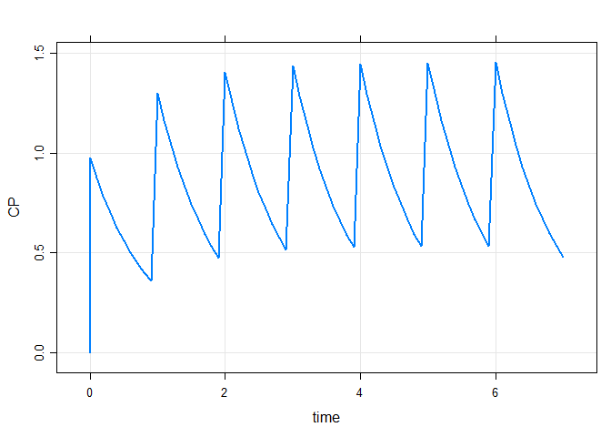

```r
easy.mrgsim(model=cmt1_iv,dosing_schedule=e1,delta=0.1,tend=7) %>% plot
```

#### 1 week of holiday between each treatment period:

```r
e2 <- seq(e1, wait = 7, e1, wait = 7)
e2
```

```
#> Events:
#>   time cmt amt evid ii addl
#> 1    0   1 150    1  1    6
#> 2   14   1 150    1  1    6
```

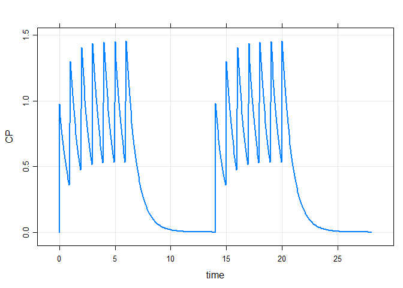

```r
easy.mrgsim(model=cmt1_iv,dosing_schedule=e2,delta=0.1,tend=7*4) %>% plot
```

#### A alternating dosing sequence: 150 mg daily for a week, then 50 mg daily for a week etc.

```r
e3 <- ev(amt = 50, ii = 1, addl = 6)
e4 <- seq(e1, e3, e1)
e4
```

```
#> Events:
#>   time cmt amt evid ii addl
#> 1    0   1 150    1  1    6
#> 2    7   1  50    1  1    6
#> 3   14   1 150    1  1    6
```

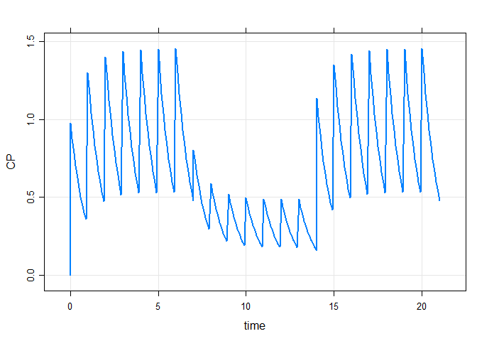

```r
easy.mrgsim(model=cmt1_iv,dosing_schedule=e4,delta=0.1,tend=7*3) %>% plot
```

#### A cycle of 3 weeks on, one week off for two months

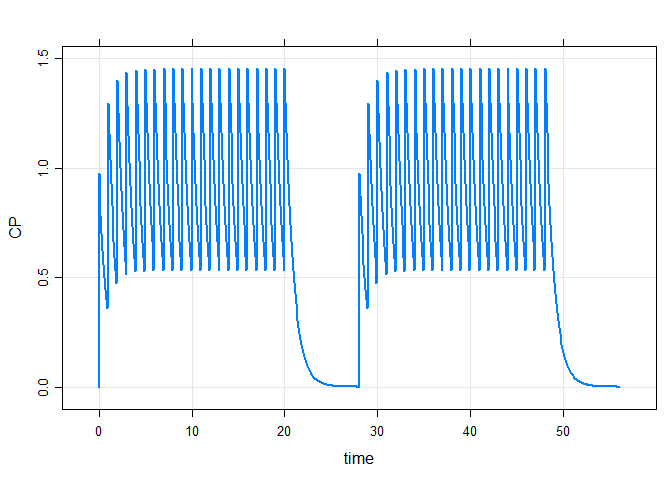

```r
e5 <- ev(amt = 150, ii = 1, addl = (3*7)-1)
e6 <- seq(e5, wait = 7, e5)
easy.mrgsim(model=cmt1_iv,dosing_schedule=e6,delta=0.1,tend=7*4*2) %>% plot
```

#### Load + maintenance doses

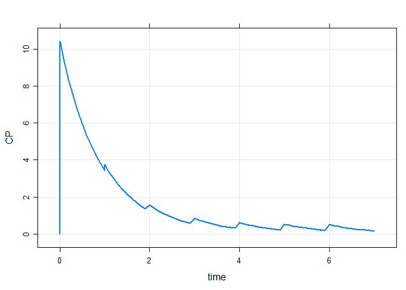

```r
#High dose: 1600mg once every week
load<- ev(amt = 1600, ii = 7, addl = 0, time=0)
#Low dose: 50mg once every day, after the high dose
maintenance<- ev(amt = 50, ii = 1, addl = 5,time=1)
easy.mrgsim(model=cmt1_iv,dosing_schedule=load+maintenance,delta=0.1,tend=7) %>% plot
```

#### Repeat this for one month period

```r
load_maint <- ev_rep(load+maintenance, n=4)
head(load_maint)
```

```
#>   time cmt  amt evid ii addl ID
#> 1    0   1 1600    1  7    0  1
#> 2    1   1   50    1  1    5  1
#> 3    7   1 1600    1  7    0  1
#> 4    8   1   50    1  1    5  1
#> 5   14   1 1600    1  7    0  1
#> 6   15   1   50    1  1    5  1
```

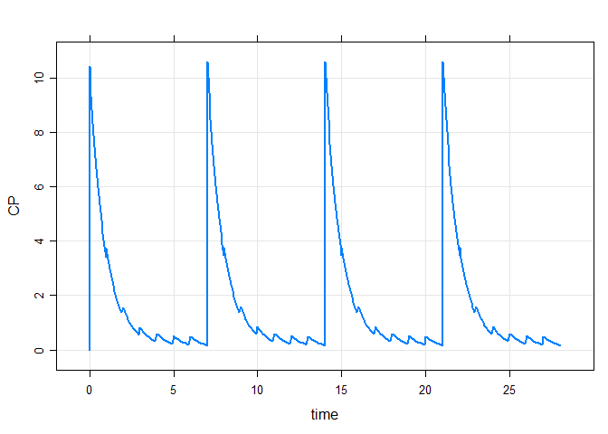

```r
easy.mrgsim(model=cmt1_iv,data=load_maint,delta=0.1,tend=7*4) %>% plot
```

### Simulate several individuals

To simulate different individuals we need to introduce variability into the pk parameters. To this end, a variance-covariance matrix needs to be defined. Let’s simulate 5 individuals, with 0.1 variance for the clearance (CL) and 0.2 variance for the volume of distribution (V).

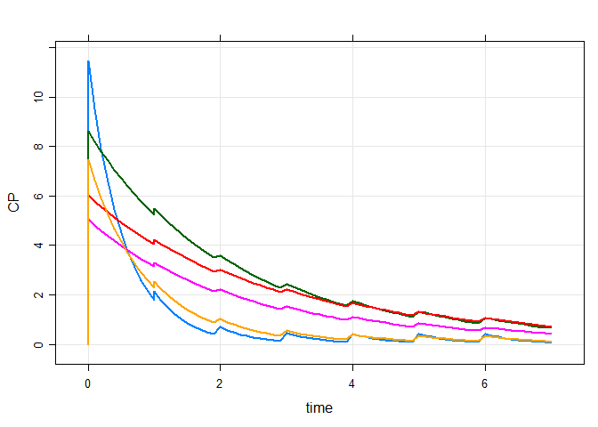

```r
Nindividuals=5
easy.mrgsim(model=cmt1_iv,dosing_schedule=load+maintenance,delta=0.1,tend=7,
            variability = dmat(0.1, 0.2),nid=Nindividuals) %>% plot
```

### Plot with ggplot2

You prefer plotting with ggplot2? Just save the results as a data.frame

```r
pk<-as.data.frame(easy.mrgsim(model=cmt1_iv,dosing_schedule=load+maintenance,delta=0.1,tend=7,
                              variability = dmat(0.1, 0.2),nid=Nindividuals) )
head(pk)
```

```
#>   ID time        CP
#> 1  1  0.0  0.000000
#> 2  1  0.0 10.221589
#> 3  1  0.1  9.287760
#> 4  1  0.2  8.439244
#> 5  1  0.3  7.668247
#> 6  1  0.4  6.967687
```

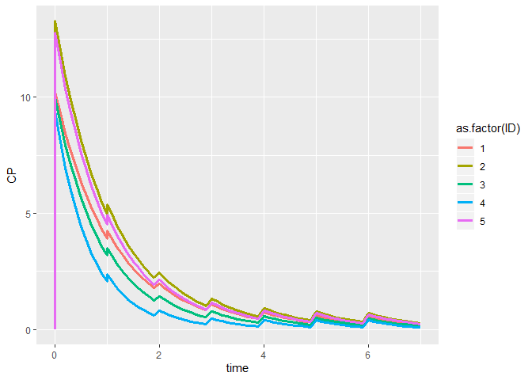

```r
library(ggplot2)
ggplot(data=pk,aes(x=time,y=CP,col=as.factor(ID)))+geom_line(size=1.3)
```

## IV infusion

For drug administration by infusion, or any zero-order input models, the rate of drug administration may be defined using the rate argument.

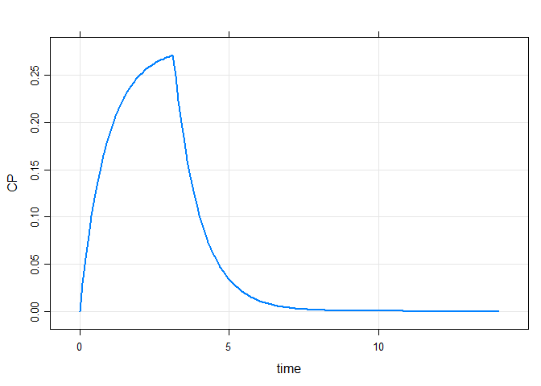

```r
inf <- ev(amt = 150, time=0, rate=48)
easy.mrgsim(model=cmt1_iv,dosing_schedule =inf,delta=0.1,tend=7*2) %>% plot
```

## Oral administration

Now we are going to simulate a one compartment model with extravascular administration. We first select a model from the model libraries already included in ACESO instead of writing all the code by ourselves:

```r
model_library(list=T)
```

```
#> ACESO internal library of PK models:
#> [1] "1cmt_2depot" "1cmt_ev"     "1cmt_iv"     "2cmt_2depot" "2cmt_ev"
#> [6] "2cmt_iv"     "3cmt_ev"     "3cmt_iv"
```

```r
cmt1_oral <- mread("1cmt_ev", model_library()) %>% Req(CP)
```

```
#> Building 1cmt_ev ...
#> done.
```

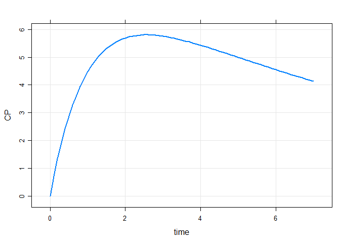

```r
oral1 <- ev(amt = 150, time=0)

easy.mrgsim(model=cmt1_oral,dosing_schedule=oral1,delta=0.1,tend=7) %>% plot
```

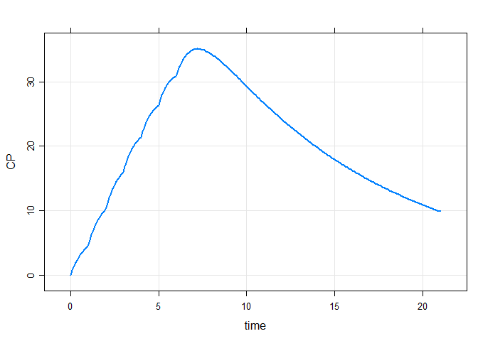

```r
oral2 <- ev(amt = 150, ii=1, addl=6, time=0)

easy.mrgsim(model=cmt1_oral,dosing_schedule=oral2,delta=0.1,tend=7*3) %>% plot
```

Introduce a lag time of 2 days

```r
#See the parameters of the model
param(cmt1_oral)
```

```
#>
#>  Model parameters (N=5):
#>  name value . name value
#>  ALAG 0     | TVKA 1
#>  F    1     | TVV  20
#>  TVCL 2     | .    .
```

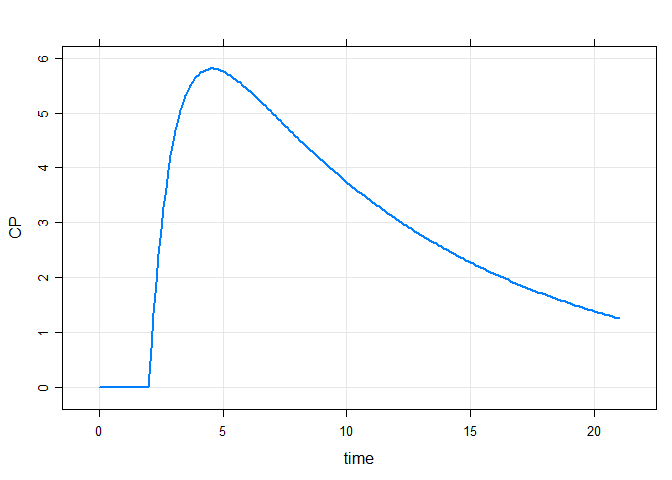

```r
#The parameter associated with the lag time is ALAG
easy.mrgsim(model=cmt1_oral,dosing_schedule=oral1,delta=0.1,tend=7*3,parameters=list(ALAG=2)) %>% plot
```